# 통계밥법론2 Chap3 실습코드

## 3.6 Fitting discrete distributions as generalized linear models

*Example 3.23: Families in Saxony*

```r
data("Saxony", package = "vcd")
Males <- as.numeric(names(Saxony))
Families <- as.vector(Saxony)
Sax.df <- data.frame(Males, Families)
```

`Saxony`데이터를 `glm`함수에 적합시키기 위해 데이터 프레임의 형태로 전환하였다.  
`glm`함수는 일반화된 선형 모델을 적합하기 위해 사용되는 함수이며, 여러가지 옵션을 활용하여 다양한 일반화된 선형 모델을 적합시킬 수 있다.  
- `glm(formula, family(link),data)`

- formula: 적합시키고자 하는 변수들의 형태
- family: 적합시키고자 하는 분포
- link: 분포에 적용할 link function
- data: glm 함수를 적용할 데이터

```r
Sax.bin <- glm(Families ~ Males, offset = lchoose(12,0:12),
               family = "poisson", data =Sax.df)
LRstats(Sax.bin)
```

```
## Likelihood summary table:
##            AIC    BIC LR Chisq Df Pr(>Chisq)
## Sax.bin 191.07 192.21   97.007 11  6.978e-16 ***
## ---
## Signif. codes:  0 '***' 0.001 '**' 0.01 '*' 0.05 '.' 0.1 ' ' 1
```

`offset`옵션을 활용하여 `Sax.df`데이터가 갖고 있는 빈도의 사전 정보를 모델이 활용할 수 있게 만들어 주었다.

`LRstats`는 `vcdExtra`패키지에 포함된 함수로, `glm`또는 `loglm`모델의 적합도에 대한 간략한 정보만을 활용하고자 할 때 사용하거나 두 모델간의 적합도 비교를 할 때 사용되기도 한다.  
- `LRstats(object)`

- object: 적합도를 살펴볼 모델 (2개 이상이 들어가는 경우, 모델 간 비교를 진행한다.)

`LRstats`를 통해 모델의 적합도 검정을 진행한 결과, 유의확률이 유의수준 0.05보다 매우 작다.  
모델의 적합도 검정을 진행하는 경우, 귀무가설과 대립가설은 아래와 같다.

H0: 주어진 모델은 적합하다. H1: 주어진 모델은 적합하지 않다.

따라서, 귀무가설을 기각하게 되므로, `Saxony`데이터를 포아송 분포로 가정한 후 `glm`을 통해 모델에 적합하는 것은 적절하지 않은 것임을 확인할 수 있다.

```r
coef(Sax.bin)
```

```
## (Intercept)       Males
## -0.06952221  0.07689805
```

추정된 선은 `y = -0.0695 + 0.076 Males`이다.

```r
Sax.df$YlogitY <-
  Males * log(ifelse(Males ==0,1,Males)) +
  (12 - Males) * log(ifelse(12-Males == 0,  1, 12-Males))

Sax.dbin <- glm(Families ~ Males + YlogitY, offset = lchoose(12,0:12),
                family = poisson, data = Sax.df)
coef(Sax.dbin)
```

```
## (Intercept)       Males     YlogitY
## -3.09691848  0.06597732  0.14020530
```

기존에 있던 데이터에 로그를 사용하여 하나의 모수를 더 추가한 후, 이중 이항분포의 형태로 만들어 준 후, `glm`에 다시 한 번 적합시켜 보았다.  
추정된 선은 `y = -3.096 + 0.066 Males + 0.140 YlogitY`이다.

```r
LRstats(Sax.bin, Sax.dbin)
```

```
## Likelihood summary table:
##             AIC    BIC LR Chisq Df Pr(>Chisq)
## Sax.bin  191.07 192.21   97.007 11  6.978e-16 ***
## Sax.dbin 109.13 110.83   13.061 10     0.2203
## ---
## Signif. codes:  0 '***' 0.001 '**' 0.01 '*' 0.05 '.' 0.1 ' ' 1
```

`LRstats`를 사용하여 포아송 분포를 가정하고 적합시킨 모델과 이중 이항분포 모델을 비교한 결과이다.  
이중 이항 분포 모델을 적합시킨 모델의 유의확률은 유의수준 0.05보다 큰 값을 가지는 것을 확인할 수 있다.  
따라서, 귀무가설을 기각하지 못하므로 **주어진 모델(이중 이항분포)은 적합한 모델**임을 알 수 있다.

```r
results <- data.frame(Sax.df,
                      fit.bin = fitted(Sax.bin),
                      res.bin = rstandard(Sax.bin),
                      fit.dbin = fitted(Sax.dbin),
                      res.dbin = rstandard(Sax.dbin))
print(results, digits = 2)
```

```
##    Males Families YlogitY fit.bin res.bin fit.dbin res.dbin
## 1      0        3      30    0.93    1.70      3.0    0.026
## 2      1       24      26   12.09    3.05     23.4    0.136
## 3      2      104      24   71.80    3.71    104.3   -0.036
## 4      3      286      23  258.48    1.87    307.8   -1.492
## 5      4      670      22  628.06    1.94    652.9    0.778
## 6      5     1033      22 1085.21   -1.87   1038.5   -0.202
## 7      6     1343      22 1367.28   -0.75   1264.2    2.635
## 8      7     1112      22 1265.63   -5.09   1185.0   -2.550
## 9      8      829      22  854.25   -1.03    850.1   -0.846
## 10     9      478      23  410.01    3.75    457.2    1.144
## 11    10      181      24  132.84    4.23    176.8    0.371
## 12    11       45      26   26.08    3.42     45.2   -0.039
## 13    12        7      30    2.35    2.45      6.5    0.192
```

포아송 분포로 적합시킨 모델과 이중 이항분포를 적합시킨 모델의 잔차와 추정값을 확인해 보았다.  
위에 결과에서 볼 수 있듯이, 이중 이항분포를 적합시킨 모델의 추정값이 실제 관찰값과 가깝고 이를 통해 잔차가 더 작은 것을 알 수 있다.

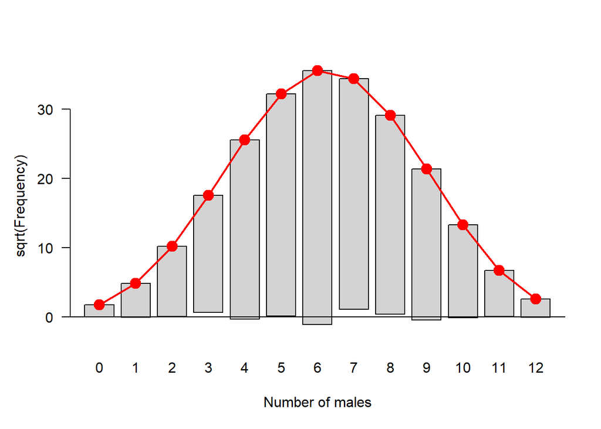

```r
with(results, vcd::rootogram(Families, fit.dbin, Males,
                            xlab = "Number of males"))
```

### 3.6.1 covariates, overdispersion, and excess zeros

```r
data("PhdPubs", package = "vcdExtra")
head(PhdPubs)
```

```
##   articles female married kid5 phdprestige mentor
## 1        0      0       1    0           3      7
## 2        0      1       0    0           2      6
## 3        0      1       0    0           4      6
## 4        0      0       1    1           1      3
## 5        0      1       0    0           4     26
## 6        0      1       1    2           4      2
```

- articles: 출판물 수 (Discrete variable)
- female: 성별 (Factor variable - 0 = Male, 1 = Female)
- married: 결혼여부 (Factor variable - = 0 married, 1 = unmarried)
- Kid5: 5살 이하의 어린 자녀의 수 (Discrete variable)
- phdprestige: 박사학위의 명성 수치 (Discrete variable)
- mentor: 3년간 멘토에 의한 출판물 수 (Discrete variable)

```r
table(PhdPubs$articles)
```

```
##
##   0   1   2   3   4   5   6   7   8   9  10  11  12  16  19
## 275 246 178  84  67  27  17  12   1   2   1   1   2   1   1
```

출판물 수는 0개부터 19개까지 있으며, 출판물을 하나도 내지 못한 박사들이 275명으로 가장 많다.

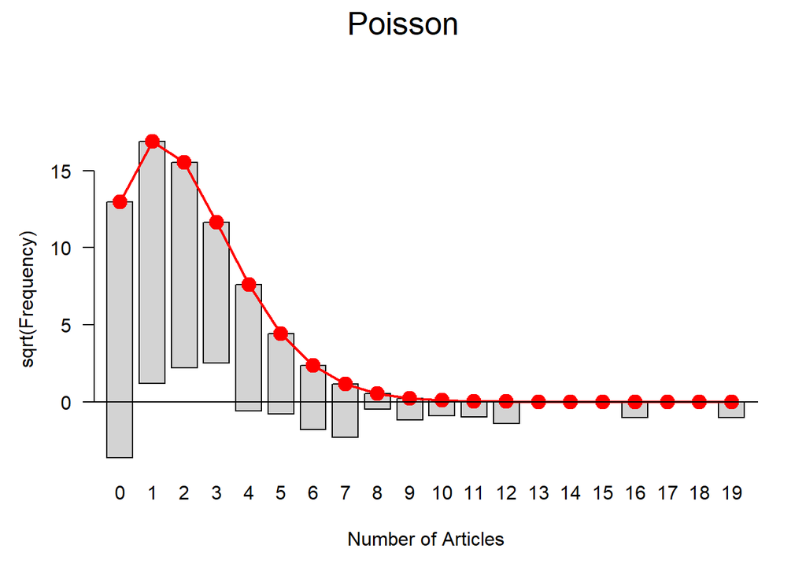

```r
library(vcd)
plot(goodfit(PhdPubs$articles), xlab = "Number of Articles",
     main = "Poisson")
```

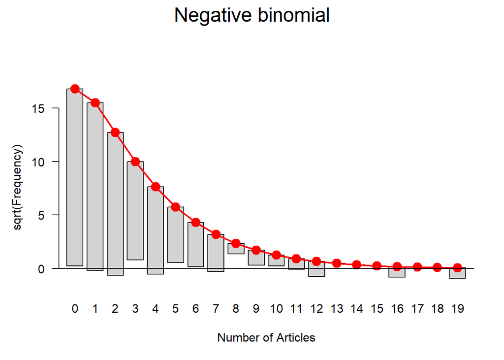

```r
plot(goodfit(PhdPubs$articles, type = "nbinomial"),
     xlab = "Number of Articles",
     main = "Negative binomial")
```

```r
summary(goodfit(PhdPubs$articles), type = "nbinomial")
```

```
##
##   Goodness-of-fit test for poisson distribution
##
##                       X^2 df     P(> X^2)
## Likelihood Ratio 296.3715 13 1.381259e-55
```

```r
summary(goodfit(PhdPubs$articles), type = "poisson")
```

```
##
##   Goodness-of-fit test for poisson distribution
##
##                       X^2 df     P(> X^2)
## Likelihood Ratio 296.3715 13 1.381259e-55
```

## Sumamry of Chapter3

- 이산형 데이터를 다룸에 있어서 다양한 이산분포를 이해하고 데이터에 적합한 후, 적합시킨 분포가 데이터에 적합한지에 대한 판단을 하는 것은 중요한 과정이다.
- **이항분포**는 성공에 대한 이산분포로 구성되며, 총 시행횟수와 성공확률 p가 주어졌을 때 각 성공시행에 대한 확률을 추정할 수 있다.
- **포아송분포**는 평균 단위시간당 발생 횟수를 알 때, 특정 단위시간에 대한 발생 확률을 추정하고자 할 때 사용한다.
- **음이항분포**는 분석자가 정한 성공횟수까지 얼마만큼의 실패가 필요하며, 그에 대한 확률을 추정하고자 할 때 사용한다.
- **기하분포**는 첫 성공까지 이전까지에 대한 실패확률을 추정할 때 사용한다.
- 이산분포가 적합한지에 대해 진단을 하는 방법은 **적합도 검정**이라는 방법을 사용한다. 이는 특정 분포를 가정 했을 때, 데이터가 가정한 분포를 따르는 것이 적합한지에 대한 검정이며, R에서는 `goodfit()`함수를 통해 쉽게 확인할 수 있다.
- 이산분포 적합가정은 시각화를 통해서도 살펴볼 수 있는데, R에서는 `rootogram`, `distplot`,`Ord_plot`을 사용하여 진단을 할 수 있다.